# LCHF GDF15 Glucose Measurements

Claire Gleason, Cody Cousineau and JeAnna Redd and Dave Bridges

July 7, 2018

This script was most recently run on Tue May 26 22:02:57 2020 and can be found in /Users/davebrid/Documents/GitHub/TissueSpecificTscKnockouts/Mouse Data/Ketogenic Diets.

# Purpose

To determine insulin responsiveness of wild-type and GDF15 knockout mice.

# Experimental Details

These were all ITTs done around 2PM after a 6h fast.

# Raw Data

The raw data can be found in KD GDF15 Knockout Raw Glucose Data.csv in the folder /Users/davebrid/Documents/GitHub/TissueSpecificTscKnockouts/Mouse Data/Ketogenic Diets. This script was most recently updated on Tue May 26 22:02:57 2020.

# Analysis

## Fasting Glucose Levels

### From a 6h Fast

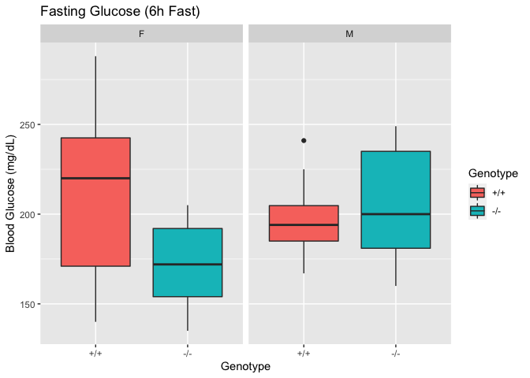

6h fasting glucose, by treatment

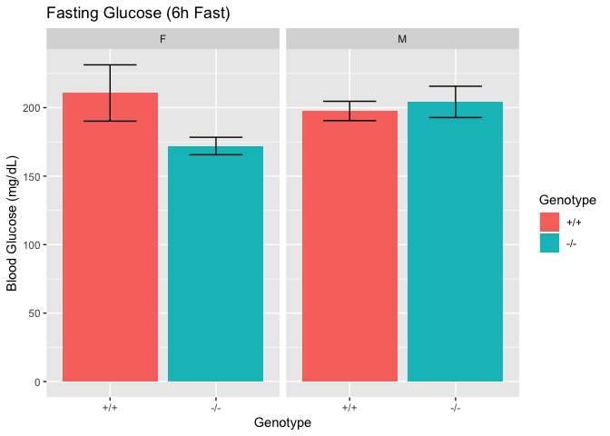

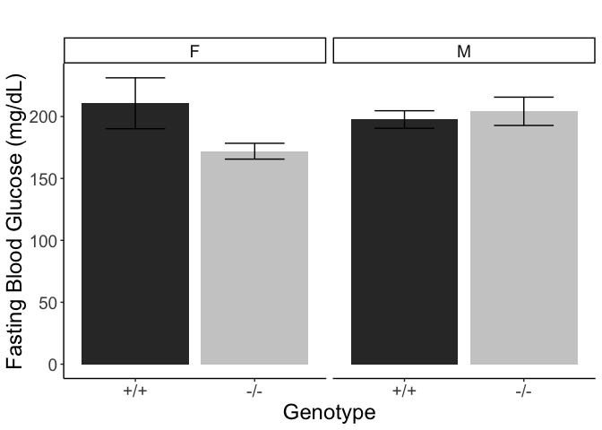

### Fasting Glucose Stats

Summary statistics for effects on fasting blood glucose

| Genotype | Sex | Avg | SE | n | shapiro |
| --- | --- | --- | --- | --- | --- |
| +/+ | F | 211 | 20.56 | 7 | 0.778 |
| +/+ | M | 198 | 7.07 | 10 | 0.571 |
| -/- | F | 172 | 6.39 | 13 | 0.459 |
| -/- | M | 204 | 11.43 | 9 | 0.333 |

2x2 ANOVA with interaction between genotype and sex for fasting glucose

| term | df | sumsq | meansq | statistic | p.value |
| --- | --- | --- | --- | --- | --- |
| Genotype | 1 | 3045 | 3045 | 2.80 | 0.103 |
| Sex | 1 | 1460 | 1460 | 1.34 | 0.254 |
| Genotype:Sex | 1 | 4770 | 4770 | 4.39 | 0.043 |
| Residuals | 35 | 38027 | 1086 | NA | NA |

Female knockout mice had a 18.373% reduction in fasting glucose (p=0.037 ) but the male mice did not (-3.351%; p=0.621). All groups were found to be normally distributed by a Shapiro-Wilk test (see above). Only males could be assumed to have equal variance via Levene’s tests (males p=0.176; females p=0.034).

## Insulin Tolerance Test

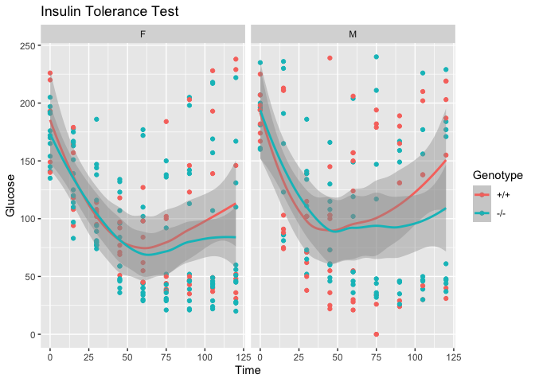

Insulin tolerance tests by genotype

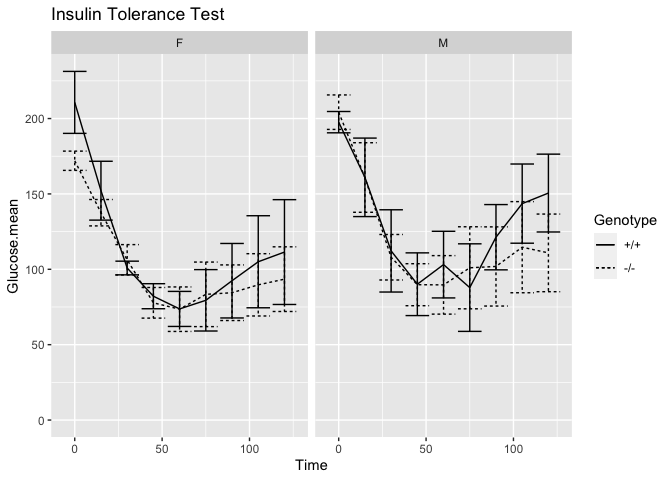

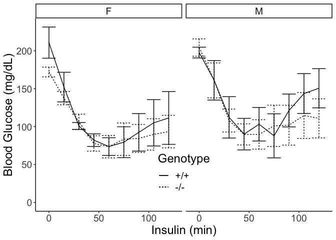

### ITT Stats

Used mixed linear models to analyze ITT’s

Mixed linear models for effects on ITT

|  | Sum Sq | Mean Sq | NumDF | DenDF | F value | Pr(>F) |
| --- | --- | --- | --- | --- | --- | --- |
| as.factor(Time) | 415812.0 | 51976.5 | 8 | 292.1 | 32.374 | 0.000 |
| Genotype | 78.8 | 78.8 | 1 | 33.9 | 0.049 | 0.826 |
| Sex | 779.2 | 779.2 | 1 | 33.9 | 0.485 | 0.491 |
| Genotype:Sex | 209.5 | 209.5 | 1 | 33.9 | 0.131 | 0.720 |

The model used was: **Glucose ~ as.factor(Time) + Genotype * Sex + (1 | MouseID)**.

## Normalized ITT Data

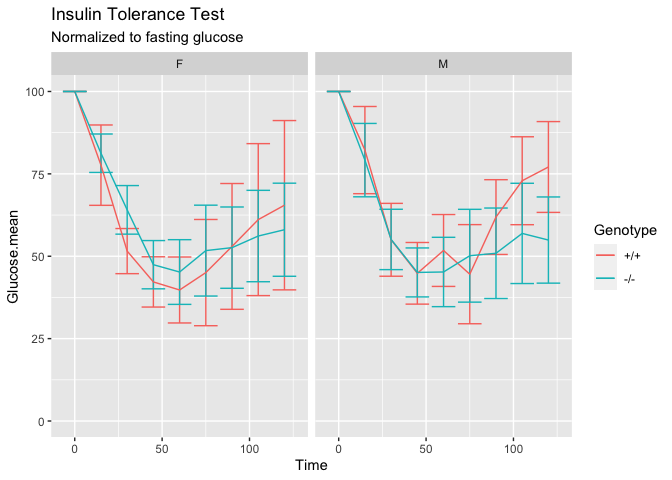

## Area Under Curve

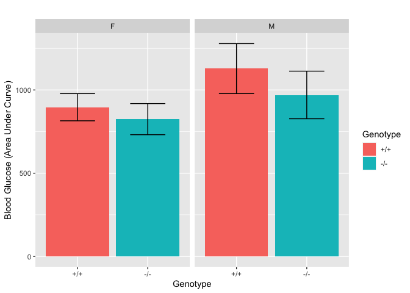

# Interpretation

There was a sex-specific reduction in fasting blood glucose, but no significant difference in glucose levels during the insulin tolerance test